# EiRb-30 Lithic Analysis

Nick Waber

2023-05-04

## 1 Introduction

Systematic data recovery (SDR) excavations yielded 69 lithics from seven excavation units at EiRb-30. The lithics are primarily fine-grained volcanic material, along with two pieces of chert. Most of the assemblage is debitage; primarily very small flakes. The debitage provides evidence of biface manufacture, and several flakes (including those from biface knapping) exhibit cortex. Three formal tools were recovered: a broken biface blank or early-stage preform, and two finished projectile points. Both points exhibit morphology consistent with the Plateau horizon (2400-1200 BP), though one also shares stylistic elements with Kamloops horizon types (1200-200 BP). Overall, the lithic assemblage represents activities one would expect at a specific-function lithic manufacturing station.

## 3 Results

### 3.1 Raw Materials

Of the 69 lithics from EiRb-30, 67 are a dark grey-to-black fine-grained extrusive volcanic rock (FGV), visually consistent with dacitic and rhyolitic material from the well-documented tool stone quarries at Arrowstone Hills, Maiden Creek, and Upper Hat Creek Valley (Rousseau 2015, 2000). It is not possible to provide a definitive source location without further geochemical/isotopic analyses, which are beyond the scope of this study.

| Table 1: EiRb-30 lithic artifact type frequencies by raw material | Table 1: EiRb-30 lithic artifact type frequencies by raw material Material chert | Table 1: EiRb-30 lithic artifact type frequencies by raw material Material fgv |
| --- | --- | --- |
| Type |  |  |
| debitage | 2 | 64 |
| formal tool | 0 | 3 |

### 3.2 Temporal and Spatial Distribution

-EU 21-02 is 17m SWW (16m W; 5.38m S) of EU 21-03. -EU 21-04 is adjacent to EU 21-06 and 21-07.

Block B Unit layout:

[21-08][21-06][21-10]

[21-09][21-04][21-07][21-05]

A total of 69 lithic artifacts and debitage were recovered from seven of ten excavation units at EiRb-30. The units were laid out with two in Block A (EU 21-01; 21-02) and eight in Block B. Two pieces of fine-grained volcanic debitage were found in EU 21-02, and the rest of the assemblage is from Block B (**Table 1-4**). In that excavation block, most of the material (n = 50) came from three units: EU 21-06, 21-07, and 21-08. Interestingly, all of the tools recovered from EiRb-30 were found in EU 21-04 rather than in the units with considerably more lithic material. This may reflect different flaking zones, flaing being undertaken by more than one person, or could also be a case of displacement or secondary deposition. Without robust evidence for the nature of the spatial patterning within those units, and given that all of the positive units from Block B are adjacent to one another, this analysis will treat that assemblage as a single analytical unit.

[output not shown]

[output not shown]

[output not shown]

[output not shown]

### 3.3 Formal Tools

EiRb-30:032 is a fragment of a biface blank or early-stage preform. The Flaking is rough, with the blade edge undulating in both plan and profile views. Interestingly, cortex or heavy patination is evident on both faces of this biface fragment, indicating that the piece on which the biface reduction was effected was already a flake or tabular stone. This presents an interesting possibility: that the knapper at EiRb-30 who was responsible for the bifacial reduction evident on this piece had collected a suitable flake from a deposit of earlier archaeological material (one with adequate antiquity to have developed substantial patina by ca. 2,000 years ago).

### 3.5 Debitage

EiRb-30 yielded 66 pieces of debitage. Most of the debitage are very small flakes; smaller than 15 mm maximum dimension with a mean mass of 0.251 g (**Table 6; Figure 3**). It is worth noting that, as seen in the central tendencies (**Table 6; Figure 4**), the mean mass is affected by nine outliers, all heavier than 0.5 g. For the purposes of interpretation, the overall debitage assemblage should be considered very small and very light.

The proportions of cortical flakes and biface reduction flakes (BRF)[^1] warrant discussion (**Table 7**). Specifically, although the moderate proportion of cortical flakes in the overall assemblage may generally be interpreted as an indicator of earlier stages of lithic reduction (following Magne 1989), in the case of EiRb-30 there is no association between the presence of cortex and evidence of bifacial reduction flaking. This was tested using Fisher’s Exact Test, comparing cortical flakes and BRF/non-BRF platform-remnant bearing flakes, which returned a non-significant result (*p* = 1). This result relates to the broken biface preform EiRb-30:032, which exhibited cortex and heavy patination on both surfaces. Specifically, the combination of cortical BRFs and the cortex on the preform shows that this specific preform was being flaked at this site, was broken during manufacture, and discarded *in situ*. As a result we may infer that mid- to late-stage biface flaking was taking place.

Fisher’s Exact test of association was used to examine size category distribution between BRF and non-BRF flakes; this returned no significant result (p = 0.5484994). While it is worth noting that nine slightly larger and heavier flakes (all over 15 mm and 0.5 g) were recovered, the results are the same whether excluding the larger flakes (p = 1) or only analyzing the larger flakes (p = 0.25). On this basis we may infer that BRFs and non-BRF PRBs share similar distributions among the observed 5mm-interval size categories, and that it is likely that all of the debitage represents bifacial flaking activities.

The two chert flakes warrant mention as well. Although the sample size of the chert assemblage is too small for meaningful technological inference or comparison to the FGV component, the presence of the chert flakes does at least indicate that the lithic reduction activities taking place at EiRb-30 were more than a single biface preform being worked (and then abandoned upon being broken). At least two chert tools were being crafted on site, as shown by the material variation in the chert debitage (Prasciunas 2014; Knell 2012; Scerri et al. 2015).

| Table 6: EiRb-30 debitage weight summary statistics n | Table 6: EiRb-30 debitage weight summary statistics mean | Table 6: EiRb-30 debitage weight summary statistics | Table 6: EiRb-30 debitage weight summary statistics Weight (g) S.D | Table 6: EiRb-30 debitage weight summary statistics Weight (g) Median | Table 6: EiRb-30 debitage weight summary statistics Weight (g) I.Q.R. | Table 6: EiRb-30 debitage weight summary statistics Weight (g) min | Table 6: EiRb-30 debitage weight summary statistics Weight (g) max |
| --- | --- | --- | --- | --- | --- | --- | --- |
| 66 | 0.251 |  | 0.382 | 0.09 | 0.1715 | 0.01 | 1.64 |

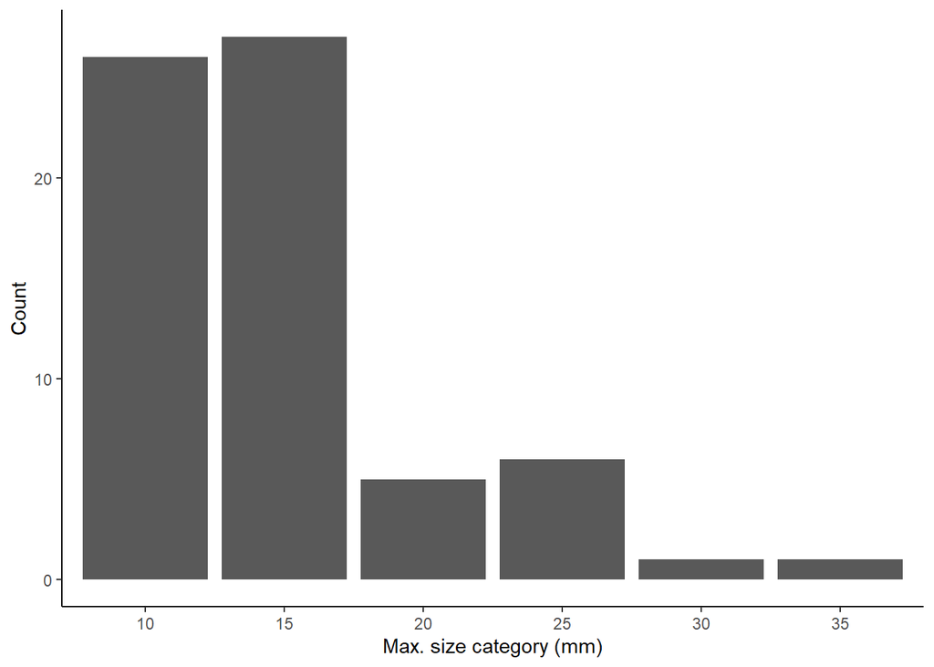

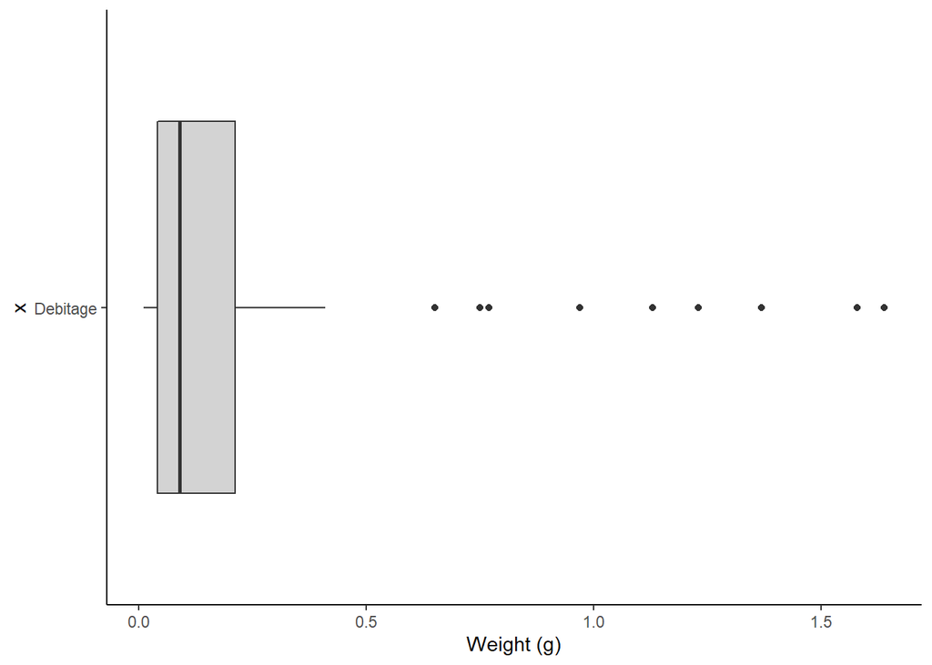

| Table 7: EiRb-30 debitage flake composition Material | Table 7: EiRb-30 debitage flake composition Count | Table 7: EiRb-30 debitage flake composition Cortex | Table 7: EiRb-30 debitage flake composition CTX % | Table 7: EiRb-30 debitage flake composition BRF | Table 7: EiRb-30 debitage flake composition BRF % |
| --- | --- | --- | --- | --- | --- |
| chert | 2 | 0 | 0 | 0 | 0 |
| fgv | 64 | 8 | 12.5 | 10 | 26.32 |
| All | 66 | 8 | 12.12 | 10 | 25.64 |

| Table 8: EiRb-30 debitage flake characteristics: platform remnant bearing flakes CTX Cortex | Table 8: EiRb-30 debitage flake characteristics: platform remnant bearing flakes CTX No cortex |
| --- | --- |
| BRF |  |
| 1 | 9 |
| 5 | 24 |

| Table 9: EiRb-30 debitage mean weight comparison: BRF vs non-BRF platform remnant bearing flakes Category | Table 9: EiRb-30 debitage mean weight comparison: BRF vs non-BRF platform remnant bearing flakes n | Table 9: EiRb-30 debitage mean weight comparison: BRF vs non-BRF platform remnant bearing flakes | Table 9: EiRb-30 debitage mean weight comparison: BRF vs non-BRF platform remnant bearing flakes Weight (g) mean | Table 9: EiRb-30 debitage mean weight comparison: BRF vs non-BRF platform remnant bearing flakes Weight (g) S.D. | Table 9: EiRb-30 debitage mean weight comparison: BRF vs non-BRF platform remnant bearing flakes Weight (g) median | Table 9: EiRb-30 debitage mean weight comparison: BRF vs non-BRF platform remnant bearing flakes Weight (g) I.Q.R. | Table 9: EiRb-30 debitage mean weight comparison: BRF vs non-BRF platform remnant bearing flakes Weight (g) min. | Table 9: EiRb-30 debitage mean weight comparison: BRF vs non-BRF platform remnant bearing flakes Weight (g) max. |
| --- | --- | --- | --- | --- | --- | --- | --- | --- |
| BRF | 10 |  | 0.194 | 0.337 | 0.08 | 0.1 | 0.03 | 1.13 |
| PRB | 56 |  | 0.261 | 0.391 | 0.12 | 0.171 | 0.01 | 1.64 |
| All | 66 |  | 0.251 | 0.382 | 0.09 | 0.171 | 0.01 | 1.64 |

## 4 Conclusions and Discussion

The EiRb-30 lithic assemblage is a relatively small collection of lithics (n = 69) composed largely of FGV debitage, three formal tools, and two chert flakes. The convergent lines of evidence presented by the broken FGV blank/preform, the FGV debitage indicative of biface manufacture, and the individual flakes of two different cherts contribute to a narrative of tool crafting on site, likely for use elsewhere. The biface blank/preform and bifacing debitage reflect manufacture of a high-quality tool designed with longer-term curation in mind (Nelson 1991; Bleed 1986; Bamforth 1986; Bamforth and Bleed 1997). The two complete projectile points present an interesting puzzle in this context: are they other products of the biface knapping on-site, dropped or lost shortly after completion and prior to use, or were they crafted independently and came to be deposited here through other circumstances? The pristine distal tips indicate that they did not suffer use-related damage, but we cannot use that as evidence against having been used; only as evidence against having recently struck a hard material (i.e. missing a target and impacting a tree/rock, or hitting a target but striking a bone). Similarly, the tools may have been re-finished on site, though the lateral margins offer no evidence of secondary modification. Given the contextual association between the majority FGV biface reduction debitage and the very good condition of the bifaces we propose that these were likely finished on-site and were lost prior to hafting. To that end, accepting the points as contemporaneous objects the most likely temporal period for the archaeological deposit is the later Plateau horizon, nearing 1200 BP. Functionally the site was likely a tool finishing/re-fitting station, based on the generally uniform debitage and the recovered tools–both complete and broken (Binford 1980; Magne 1989).

### References

Bamforth, Douglas B. 1986. “Technological Efficiency and Tool Curation.” *American Antiquity* 51 (1): 38–50. http://www.jstor.org/stable/280392.

Bamforth, Douglas B., and Peter Bleed. 1997. “Technology, Flaked Stone Technology, and Risk.” *Archaeological Papers of the American Anthropological Association* 7 (1): 109–39. https://doi.org/10.1525/ap3a.1997.7.1.109.

Binford, Lewis R. 1980. “Willow Smoke and Dogs’ Tails: Hunter-Gatherer Settlement Systems and Archaeological Site Formation.” *American Antiquity* 45 (1): 4–20.

Bleed, Peter. 1986. “The Optimal Design of Hunting Weapons: Maintainability or Reliability.” *American Antiquity* 51 (4): 737–47. http://www.jstor.org/stable/280862.

Knell, Edward J. 2012. “Minimum Analytical Nodules and Late Paleoindian Cody Complex Lithic Technological Organization at Hell Gap, Wyoming.” *Plains Anthropologist* 57 (224): 325–51. https://doi.org/10.1179/pan.2012.024.

Magne, Martin P. R. 1989. “Lithic Reduction Stages and Assemblage Formation Processes.” In, edited by Daniel S. Amick and Raymond P. Mauldin, 15–31. Oxford: B.A.R. International Series. papers://615a4f4f-b055-4473-890f-e54cd7661df9/Paper/p175.

Nelson, Margaret C. 1991. “The Study of Technological Organization.” Edited by Michael B Schiffer. *Archaeological Method and Theory Vol.3* 3 (1991): 57–100. http://www.jstor.org/stable/20170213.

Prasciunas, Mary M. 2014. “Analytical Flaked Stone Nodules and Clovis Technological Organization at the Sheaman Site, Wyoming.” In, edited by Douglas H. MacDonald, William, Jr. Andrefsky, and Pei-Lin Yu, 52–74. Missoula, MT: University of Montana Press.

Rousseau, Mike K. 2000. “Results of the Keatley Creek Archaeological Project Lithic Source Study.” In, edited by Brian Hayden, 165–84. Burnaby, BC: SFU Archaeology Press.

———. 2015. “Primary Toolstone Sources and Pre-Contact Period Quarrying Behaviour in the Thompson River Drainage of South Central British Columbia.” In, edited by Terry L. Ozbun and Ron L. Adams, 29–48. Burnaby, BC: SFU Archaeology Press.

Scerri, Eleanor M. L., Brad Gravina, James Blinkhorn, and Anne Delagnes. 2015. “Can Lithic Attribute Analyses Identify Discrete Reduction Trajectories? A Quantitative Study Using Refitted Lithic Sets.” *Journal of Archaeological Method and Theory*. https://doi.org/10.1007/s10816-015-9255-x.